# SLV Practical Week 6

# Final assignment: random forest for classification

**15. Use the function `randomForest()` to create a random forest model on the iris dataset. Use the function `importance()` on this model and create a bar plot of variable importance. Does this agree with your expectations? How well does the random forest model perform compared to the `lda_iris` model?**

Petal (width) is the more important variable.

The random forest model performs slightly worse

```r
# Random forest model
rf_mod <- randomForest(Species ~ ., data = iris)

rf_mod
```

```
##
## Call:
##  randomForest(formula = Species ~ ., data = iris)
##                Type of random forest: classification
##                      Number of trees: 500
## No. of variables tried at each split: 2
##
##         OOB estimate of  error rate: 6%
## Confusion matrix:
##            setosa versicolor virginica class.error
## setosa         50          0         0        0.00
## versicolor      0         47         3        0.06
## virginica       0          6        44        0.12
```

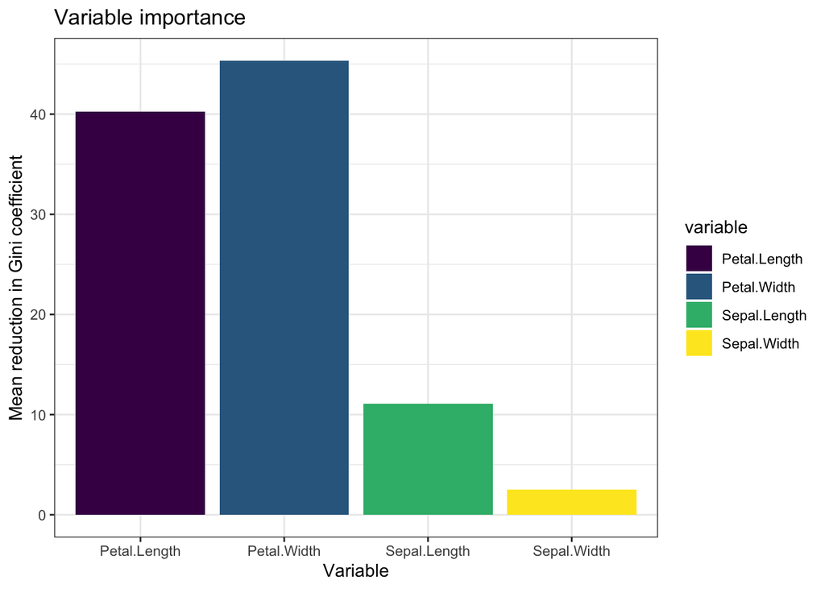

```r
# Variable importance
var_imp <- importance(rf_mod)

# Create tibble
tibble(
  importance = c(var_imp),
  variable = rownames(var_imp)) %>%
  ggplot(aes(x = variable, y = importance, fill = variable)) +
  geom_bar(stat = "identity") +
  labs(x = "Variable",
       y = "Mean reduction in Gini coefficient",
    title = "Variable importance") +
    scale_fill_viridis_d() +
    theme_bw()
```